# xxx. GGIS 224 Tutorial. Watershed analysis

3/25/2024

## 1 Introduction

Source: https://vt-hydroinformatics.github.io/rgeowatersheds.html, modified by Jida Wang (GGIS@UIUC)

To read in detail about any of the WhiteboxTools used in this activity, check out the user manual: https://jblindsay.github.io/wbt_book/intro.html. More about WhiteboxTools: https://www.whiteboxgeo.com/manual/wbt_book/intro.html

This activity is adapted from/inspired by: https://matthewrvross.com/active.html and other code from Nate Jones.

Goals for this activity:

Use R to delineate the watershed for several pour points on a DEM Extract topographic information from those watersheds

Check out the list of packages for this exercise.

```r
library(tidyverse)
library(raster)
library(sf)
library(tmap)
library(stars)
library(rgl)
library(terra)
library(dplyr)
library(spData)
library(spDataLarge)

#install.packages("rayshader")
library(rayshader)

#install.packages("whitebox", repos="http://R-Forge.R-project.org")
library(whitebox)
whitebox::wbt_init()
```

## 2 Overview of the watershed delineation process

With watershed delineation, it is helpful to take a step back and think about how the whole process works before we dive in. The way things are presented below is pretty linear, but there is no way you would arrive at it by just trying to fire up the watershed delineation function in whitebox. It took some planning to figure out this process! So let’s work through it…

We will use the wbt_watershed() function to delineate our watersheds. This function looks upslope from a given point or points (i.e., the pour point(s)) and figures out what area drains to that point. To run this function you need a D8 pointer grid (i.e., D8 flow direction) and a pour point, or pour points. We have to do a few things to generate those two inputs.

Generating the D8 pointer grid: this is a grid where each cell specifies what direction water will flow out of that cell. So if our DEM has any pits or depressions without outlets in it, there will be flow dead-ends (sinks or pits). This will result in an incorrect/interrupted watershed delineation. So we have to prepare our DEM to get rid of pits/depressions.

We will do this in two stages. First we will fill single cell pits and then breach larger depressions. It is important to remember that for this to work you have to fill the single cell depressions, then pass the resulting DEM from that process to the breach depression function. Once you have done this, you can run the D8 pointer function to generate your pointer grid (flow direction raster).

Making pour points: The key here is that your pour points MUST be on ones of the cells in the “stream”, according to your DEM. If it is even one cell over from the high flow accumulation cells that denote the stream on your DEM, you will just get a weird, small sliver of a watershed.

The first step is to get the coordinates of your pour point(s). You could grab them from Google Maps, use a GPS in the field, or maybe you have coordinates for a known location/structure that defines your “outlet”. This could be a flume, weir, dam, gaging station, etc. Even if your coordinates came from the super fanciest differential nanometer accuracy wonder GPS, you STILL need to use the process described below to ensure they are on your flow network. Your points might be in the right place, but that doesn’t mean that’s where the stream is according to your DEM!

You can read your points in as a csv or just define them in your code if there aren’t many (that’s what we will do) and then turn them into a spatial object using SpatialPoints(), and then export them as a shapefile. If you are reading in a shapefile with your points, you don’t need to convert/export them.

With our points in hand, we then need to make sure they are on our stream network. To do that we will use Jensen snap pour points function in wbt. This tool takes your points, searches within a defined area for the stream network, then moves the points to the stream network. This function needs your pour points and a raster stream file. So, we need to make the raster stream file! We do this using the extract streams wbt function. This function takes a D8 flow accumulation grid, so we need to create that first. Then we can run the stream network function and the snap pour points function.

SO! Our process will look like this: Read in DEM Fill single cell sinks then breach breach larger sinks Create D8 flow accumulation and D8 pointer grids (D8 flow direction) Read in pour points Create stream raster Snap pour points to stream raster Run watershed function There will be some extra steps in there just to aid in visualization, but if you were just writing code to perform the analysis, the above is the ticket

Let’s get started…

## 3 Read in DEM

First we will read in the raster, check and set its CRS (not always needed), and plot the DEM to be sure everything is ok.

```r
#Change default tmap_mode('plot') to tmap_mode('view') which is the interactive  view.
tmap_mode("view")
```

```
## tmap mode set to interactive viewing
```

```r
#Define your own working directory
my_directory = r"(D:\E\Teaching\UIUC\GGIS224\Labs\Lab9)"
setwd(my_directory)

#Load an example DEM from the spDataLarge package.
dem = rast(system.file("raster/dem.tif", package = "spDataLarge"))
writeRaster(dem, "dem.tif", overwrite = TRUE) #save this DEM to your local directory again, which ensures the format is compatible with WhiteboxTools.

#Re-read the dem.
dem = rast("dem.tif")

# Visualize the DEM
# Note: if your DEM is large (e.g., ncol or nrow > 1000, yielding more than 1 million pixels!), mapping it using tm_shape can be slow.
#As a workaround, I here apply an IF condition: if the raster size is small, map it the way it is; otherwise, speed up the visualization using the tricks below (which will NOT alter the original raster file):
#Step 1: re-sample the raster with a downscale factor (here 10 x 10 times)
#Step 2: Set the argument "raster.downsample = TRUE". This argument is ignored if the DEM size is smaller than R's environmental setting (default 1000)
if (ncol(dem)<1000 & nrow(dem)<1000)
{
  tm_shape(dem)+
    tm_raster(style = "cont", palette = "PuOr", legend.show = TRUE)+
    tm_scale_bar()
} else {
  tm_shape(aggregate(dem, 10), raster.downsample = TRUE)+
    tm_raster(style = "cont", palette = "PuOr", legend.show = TRUE)+
    tm_scale_bar()
}
```

[interactive chart not shown]

```r
#Where this DEM is located? Use the interactive view to figure it out.
```

## 4 View the DEM via hillshade

Next, we will generate a hillshade to aid in visualization and then plot it to be sure it turned out ok.

Note: this step is NOT necessary for watershed analysis.

We did not talk about hillshade during the lecture. It is mainly used for enhancing the visualization of a DEM using solar illumination (as if what we will see in our eyes). See more about what a hillshade is here: https://earthquake.usgs.gov/education/geologicmaps/hillshades.php.

```r
### !!! NOTE: Recommend to specify the full file name (including the full directory) for WhiteboxTools! See the example below.
wbt_hillshade(dem = paste0(my_directory, "/dem.tif"),  output = paste0(my_directory, "/hillshade.tif"), azimuth = 300) #Here azimuth number was arbitrarily set.
```

```
## [1] "hillshade - Elapsed Time (excluding I/O): 0.8s"
```

```r
#See more: https://rdrr.io/github/giswqs/whiteboxR/man/wbt_hillshade.html

#Read the produced hillshade
hillshade = raster("hillshade.tif")

# Map the hillshade
if (ncol(hillshade)<1000 & nrow(hillshade)<1000)
{
  tm_shape(hillshade)+
    tm_raster(style = "cont",palette = "-Greys", legend.show = FALSE)+
    tm_scale_bar()
} else {
  tm_shape(aggregate(hillshade, 10), raster.downsample = TRUE)+
    tm_raster(style = "cont",palette = "-Greys", legend.show = FALSE)+
    tm_scale_bar()
}
```

[interactive chart not shown]

## 5 Prepare DEM for Hydrology Analyses

We will fill in the DEM to remove pseudo sinks. Basically we are looking upslope for all DEM cells that drain to a specific point, so if there are any dead-ends, we will not get an accurate watershed.

In order to be sure all of our terrain drains downslope, fill single cell pits and then breach any other depressions using the wbt_breach_depressions_least_cost() function from wbt.

From now on in the analysis be careful to use the filled and breached DEM!

```r
#fill the DEM
wbt_fill_single_cell_pits(dem = paste0(my_directory, "/dem.tif"),  output = paste0(my_directory, "/dem_filled.tif"))
```

```
## [1] "fill_single_cell_pits - Elapsed Time (excluding I/O): 0.8s"
```

```r
#See more: https://rdrr.io/github/giswqs/whiteboxR/man/wbt_fill_single_cell_pits.html

wbt_breach_depressions_least_cost(
  dem = paste0(my_directory, "/dem_filled.tif"),
  output = paste0(my_directory, "/dem_breached.tif"),
  dist = 5,
  fill = TRUE)
```

```
## [1] "breach_depressions_least_cost - Elapsed Time (excluding I/O): 0.14s"
```

```r
#See more: https://rdrr.io/rforge/whitebox/man/wbt_breach_depressions_least_cost.html

wbt_fill_depressions_wang_and_liu(
  dem = paste0(my_directory, "/dem_breached.tif"),
  output = paste0(my_directory, "/dem_filled_breached.tif"),
)
```

```
## [1] "fill_depressions_wang_and_liu - Elapsed Time (excluding I/O): 0.4s"
```

```r
#See more: https://rdrr.io/rforge/whitebox/man/wbt_fill_depressions_wang_and_liu.html

#Read the smoothed dem
dem = rast("dem_filled_breached.tif")

#Map the DEM
if (ncol(dem)<1000 & nrow(dem)<1000)
{
  tm_shape(dem)+
    tm_raster(style = "cont", palette = "PuOr", legend.show = TRUE)+
    tm_scale_bar()
} else {
  tm_shape(aggregate(dem, 10), raster.downsample = TRUE)+
    tm_raster(style = "cont", palette = "PuOr", legend.show = TRUE)+
    tm_scale_bar()
}
```

[interactive chart not shown]

```r
#By now, fits in the DEM should have been filled!
```

## 6 Create flow accumulation and pointer grids (flow direction)

The watershed delineation process requires a D8 flow accumulation grid and a D8 pointer file. The flow accumulation grid is a raster where each cell is the area that drains to that cell, and the pointer file is a raster where each cell has a value that specifies which direction water would flow downhill away from that cell.

Below, create these two rasters using the filled and breached DEM.

```r
#Generate the flow accumulation map. Make sure to use the filled DEM "dem_filled_breached.tif"!!
wbt_d8_flow_accumulation(input = paste0(my_directory, "/dem_filled_breached.tif"), output = paste0(my_directory, "/D8FA.tif"))
```

```
## [1] "d8_flow_accumulation - Elapsed Time (excluding I/O): 0.129s"
```

```r
#See more: https://rdrr.io/github/giswqs/whiteboxR/man/wbt_d8_flow_accumulation.html

#Read the produced flow accumulation file
wbt_d8_flow_accumulation_lyr = rast("D8FA.tif")

#Visualize the flow accumulation map
if (ncol(wbt_d8_flow_accumulation_lyr)<1000 & nrow(wbt_d8_flow_accumulation_lyr)<1000)
{
  tm_shape(wbt_d8_flow_accumulation_lyr)+
    tm_raster(style = "quantile", legend.show = TRUE)+ #Fisher or quantile classification method is used to enhance visualization for flow accumulation (distribution dominated by small values)
    tm_scale_bar()
} else {
  tm_shape(aggregate(wbt_d8_flow_accumulation_lyr, 10), raster.downsample = TRUE)+
    tm_raster(style = "quantile", legend.show = TRUE)+ #Fisher or quantile classification method is used to enhance visualization for flow accumulation (distribution dominated by small values)
    tm_scale_bar()
}
```

[interactive chart not shown]

```r
#Generate the flow direction (pointer) map
wbt_d8_pointer(dem = paste0(my_directory, "/dem_filled_breached.tif"), output = paste0(my_directory, "/D8pointer.tif"))
```

```
## [1] "d8_pointer - Elapsed Time (excluding I/O): 0.7s"
```

```r
#See more: https://rdrr.io/cran/whitebox/man/wbt_d8_pointer.html

#Read the produced flow direction file
wbt_d8_pointer_lyr = rast("D8pointer.tif")

#Visualize the flow direction map
if (ncol(wbt_d8_pointer_lyr)<1000 & nrow(wbt_d8_pointer_lyr)<1000)
{
  tm_shape(wbt_d8_pointer_lyr)+
    tm_raster(style = "cont", legend.show = TRUE)+
    tm_scale_bar()
} else {
  tm_shape(aggregate(wbt_d8_pointer_lyr, 10, fun = modal), raster.downsample = TRUE)+ #here modal function is used for aggregating the discrete D8 flow directions.
    tm_raster(style = "cont", legend.show = TRUE)+
    tm_scale_bar()
}
```

[interactive chart not shown]

## 7 Setting pour points

The last thing we need is our pour points. These are the point locations for which we will delineate our watersheds. As previously explained, it is crucial that these points are on the stream network in each watershed. If the points are even one cell off to the side, you will not get a valid watershed. Instead you will end up with a tiny sliver that shows the area that drains to that one spot on the landscape.

Even with highly accurate GPS locations, we still need to check to be sure our pour points are on the stream network, because the DEM might not line up perfectly with the points.

Fortunately, there is a wbt function that will make sure our points are on the stream network. wbt.jenson_snap_pour_points() looks over a defined distance from the points you pass it for closest stream and then moves the points to those locations. So to use this function we also need to create a stream network.

We will follow the following process to get our pour points set up:

Create dataframe with pour points Convert data frame to shapefile Write the shapefile to our data directory Move points with snap pour points function

```r
#I grab two pour points that I am interested in with reference to the Google Maps. They are in latitude and longitude.
ppoints <- tribble(
  ~Lon, ~Lat,
  -78.298, -9.643,
  -78.312, -9.642,
)

#Create dataframe with pour points (make sure to set up the correct spatial coordinate system)
ppointsSP <- SpatialPoints(ppoints, proj4string = CRS("+proj=longlat +datum=WGS84")) #

#Convert data frame to shapefile and write the shapefile to our data directory
shapefile(ppointsSP, filename = "pourpoints.shp", overwrite = TRUE)

#Read the shapefile
ppointsSP_gcs = st_read("pourpoints.shp")
#===================================================================================================================================
#IMPORTANT: make sure to transform the spatial coordinate system of the pour point shapefile to the same one used by the filled DEM!
st_crs(dem) #Check the coordinate system for the filled DEM: ["EPSG",32717], representing WGS 1984 UTM Zone 17S
```

```
## Coordinate Reference System:
##   User input: WGS 84 / UTM zone 17S
##   wkt:
## PROJCRS["WGS 84 / UTM zone 17S",
##     BASEGEOGCRS["WGS 84",
##         DATUM["World Geodetic System 1984",
##             ELLIPSOID["WGS 84",6378137,298.257223563,
##                 LENGTHUNIT["metre",1]]],
##         PRIMEM["Greenwich",0,
##             ANGLEUNIT["degree",0.0174532925199433]],
##         ID["EPSG",4326]],
##     CONVERSION["UTM zone 17S",
##         METHOD["Transverse Mercator",
##             ID["EPSG",9807]],
##         PARAMETER["Latitude of natural origin",0,
##             ANGLEUNIT["degree",0.0174532925199433],
##             ID["EPSG",8801]],
##         PARAMETER["Longitude of natural origin",-81,
##             ANGLEUNIT["degree",0.0174532925199433],
##             ID["EPSG",8802]],
##         PARAMETER["Scale factor at natural origin",0.9996,
##             SCALEUNIT["unity",1],
##             ID["EPSG",8805]],
##         PARAMETER["False easting",500000,
##             LENGTHUNIT["metre",1],
##             ID["EPSG",8806]],
##         PARAMETER["False northing",10000000,
##             LENGTHUNIT["metre",1],
##             ID["EPSG",8807]]],
##     CS[Cartesian,2],
##         AXIS["(E)",east,
##             ORDER[1],
##             LENGTHUNIT["metre",1]],
##         AXIS["(N)",north,
##             ORDER[2],
##             LENGTHUNIT["metre",1]],
##     USAGE[
##         SCOPE["Navigation and medium accuracy spatial referencing."],
##         AREA["Between 84°W and 78°W, southern hemisphere between 80°S and equator, onshore and offshore. Ecuador. Peru."],
##         BBOX[-80,-84,0,-78]],
##     ID["EPSG",32717]]
```

```r
ppointsSP_prj = st_transform(ppointsSP_gcs, crs="EPSG:32717") #Transform the coordinate system
#===================================================================================================================================

st_write(ppointsSP_prj, "ppointsSP_prj.shp", layer_options = 'OVERWRITE=YES', update = TRUE) #Save the result as a new shapefile.
```

```
## Updating layer `ppointsSP_prj' to data source `ppointsSP_prj.shp' using driver `ESRI Shapefile'
## options:        OVERWRITE=YES
## Updating existing layer ppointsSP_prj
## Writing 2 features with 1 fields and geometry type Point.
```

Now, we will create a raster stream grid using a threshold flow accumulation of 50 cells using the D8 flow accumulation grid.

IMPORTANT: The channelization threshold varies with the study purpose and region. The rule is that you must use a channelization threshold that returns a stream network detailed enough to snap the pour points.

Based on my exploration, a threshold of 50 cells returns a sufficiently detailed network to snap the pour points.

Then finally, we will use the Jenson snap pour points function to move the pour points to their correct location.

The parameter snap_dist tells the function what distance in which to look for a stream. The units of the files we are using are meters (i.e., the unit of the UTM coordinate system). Based on my exploration, a distance of 150 m works well to snap the pour points to the stream network.

After you get the streams and snapped pour points, read them into your R environment and plot them to be sure the pour points are on the streams.

```r
wbt_extract_streams(flow_accum = paste0(my_directory, "/D8FA.tif"),
                    output = paste0(my_directory, "/raster_streams.tif"),
                    threshold = 50) #think about how large of a land area this channelization threshold represents. 1 cell in this DEM is about 30 m.
```

```
## [1] "extract_streams - Elapsed Time (excluding I/O): 0.6s"
```

```r
#See more: https://rdrr.io/github/giswqs/whiteboxR/man/wbt_extract_streams.html

wbt_jenson_snap_pour_points(pour_pts = paste0(my_directory, "/ppointsSP_prj.shp"),
                            streams = paste0(my_directory, "/raster_streams.tif"),
                            output = paste0(my_directory, "/snappedpp.shp"),
                            snap_dist = 150) #Again, be careful with this! Know the units of your data.
```

```
## [1] "jenson_snap_pour_points - Elapsed Time (excluding I/O): 0.0s"
```

```r
#See more: https://rdrr.io/github/giswqs/whiteboxR/man/wbt_jenson_snap_pour_points.html

#Read the produced files
streams <- raster("raster_streams.tif") #Read the generated stream network
pp = shapefile("snappedpp.shp") #Read the snapped pour points

#Visualize the pour points BEFORE being snapped to the network.
if (ncol(streams)<1000 & nrow(streams)<1000)
{
  tm_shape(streams)+
    tm_raster(legend.show = TRUE, palette = "Blues")+
    tm_shape(ppointsSP_prj)+
    tm_dots(col = "red")
} else {
  tm_shape(aggregate(streams, 10, fun = max), raster.downsample = TRUE)+ #downsample function set to be MAX to improve continuity of the stream network.
    tm_raster(legend.show = TRUE, palette = "Blues")+
    tm_shape(ppointsSP_prj)+
    tm_dots(col = "red")
}
```

[interactive chart not shown]

```r
#Pause: take a look at the map before snapping

#Visualize the pour points AFTER being snapped to the network.
if (ncol(streams)<1000 & nrow(streams)<1000)
{
  tm_shape(streams)+
    tm_raster(legend.show = TRUE, palette = "Blues")+
    tm_shape(pp)+
    tm_dots(col = "red")
} else {
  tm_shape(aggregate(streams, 10, fun = max), raster.downsample = TRUE)+ #downsample function set to be MAX to improve continuity of the stream network.
    tm_raster(legend.show = TRUE, palette = "Blues")+
    tm_shape(pp)+
    tm_dots(col = "red")
}
```

[interactive chart not shown]

```r
#Do you see the pour points are now well snapped to the stream network?
```

## 8 Delineate watersheds

Now we are all set to delineate our watersheds!

Use wbt_watershed(), which takes as input a D8 pointer file (d8_pntr) and the snapped pour points (pour_pts). It will output a raster where each watershed is populated with a unique value and all other cells are NA.

Read the results of this function back in and plot them over the hillshade with alpha (transparency) set to 0.5 to see what it did.

```r
wbt_watershed(d8_pntr = paste0(my_directory,"/D8pointer.tif"),
              pour_pts = paste0(my_directory,"/snappedpp.shp"),
              output = paste0(my_directory,"/watersheds.tif"))
```

```
## [1] "watershed - Elapsed Time (excluding I/O): 0.4s"
```

```r
#See more: https://rdrr.io/cran/whitebox/man/wbt_watershed.html

#Read the produced watershed file
ws = raster("watersheds.tif") #Read the watershed raster file

#Visualize the watersheds
if (ncol(hillshade)<1000 & nrow(hillshade)<1000)
{
  tm_shape(hillshade)+
    tm_raster(style = "cont",palette = "-Greys", legend.show = FALSE)+
    tm_shape(ws)+
    tm_raster(legend.show = TRUE, alpha = 0.5, style = "cat")+
    tm_shape(pp)+
    tm_dots(col = "red")
} else {
  tm_shape(aggregate(hillshade, 10), raster.downsample = TRUE)+
    tm_raster(style = "cont",palette = "-Greys", legend.show = FALSE)+
    tm_shape(aggregate(ws, 10, fun = max), raster.downsample = TRUE)+
    tm_raster(legend.show = TRUE, alpha = 0.5, style = "cat")+
    tm_shape(pp)+
    tm_dots(col = "red")
}
```

[interactive chart not shown]

## 9 Convert watersheds to shapefiles

For mapping or vector analysis it can be very useful to have your watersheds as polygons. To do this we will use the stars package. st_as_stars() converts our watershed raster into an object that the stars package can work with, and then st_as_sf() converts the raster stars object to a vector sf object. We also need to set merge to TRUE, which tells st_as_sf to treat each clump of cells with the same value (our watersheds) as its own feature.

Now we can plot the vector versions of our watersheds.

```r
#Checking watershed ID values and pixel counts
freq(ws)
```

```
##      value count
## [1,]     5  1377
## [2,]     6  1179
## [3,]    NA 11133
```

```r
#Convert watershed to shapefile
wsshape = st_as_stars(ws) %>% st_as_sf(merge = T)

#Check if there are more watershed polygons than your pour points. This may happen if any of your watersheds happens to have a very narrow section (connected only through a vertex), causing the watershed to be broken into several polygons. If this happens, we will need to dissolve (combine) the polygons based on their unique watershed IDs. See the script below.
wsshape #check the number of watershed polygons.
```

```
## Simple feature collection with 2 features and 1 field
## Geometry type: POLYGON
## Dimension:     XY
## Bounding box:  xmin: 795000.2 ymin: 8932268 xmax: 796789.5 ymax: 8934829
## Projected CRS: WGS 84 / UTM zone 17S
##   watersheds                       geometry
## 1          5 POLYGON ((796265 8934829, 7...
## 2          6 POLYGON ((795555.5 8934706,...
```

```r
wsshape_dissolved <- wsshape %>%
  group_by(watersheds) %>% #here "watersheds" is the attribute representing the watershed ID values. This attribute should be consistent with the name of your watershed tif (e.g., watersheds.tif).
  summarise()

st_write(wsshape_dissolved, 'watersheds_shape.shp', layer_options = 'OVERWRITE=YES', update = TRUE) #Save the shapefile in your directory.
```

```
## Updating layer `watersheds_shape' to data source `watersheds_shape.shp' using driver `ESRI Shapefile'
## options:        OVERWRITE=YES
## Updating existing layer watersheds_shape
## Writing 2 features with 1 fields and geometry type Polygon.
```

```r
#Visualize the vectorized watersheds
if (ncol(hillshade)<1000 & nrow(hillshade)<1000)
{
  tm_shape(hillshade)+
    tm_raster(style = "cont",palette = "-Greys", legend.show = FALSE)+
    tm_shape(wsshape_dissolved)+
    tm_borders(col = "red")
} else {
  tm_shape(aggregate(hillshade, 10), raster.downsample = TRUE)+
    tm_raster(style = "cont",palette = "-Greys", legend.show = FALSE)+
    tm_shape(wsshape_dissolved)+
    tm_borders(col = "red")
}
```

[interactive chart not shown]

## 10 Extract and analyze data based on watershed boundaries

Now, we can look at the landscape data for each watershed. To do this we will use the extract() function to extract elevation data for just the watershed shapes (vector version). Then we will grab the data for each watershed, since the output here is a list, and plot them in separate geoms in ggplot.

We can then compare how surface topography is distributed in between the two watersheds.

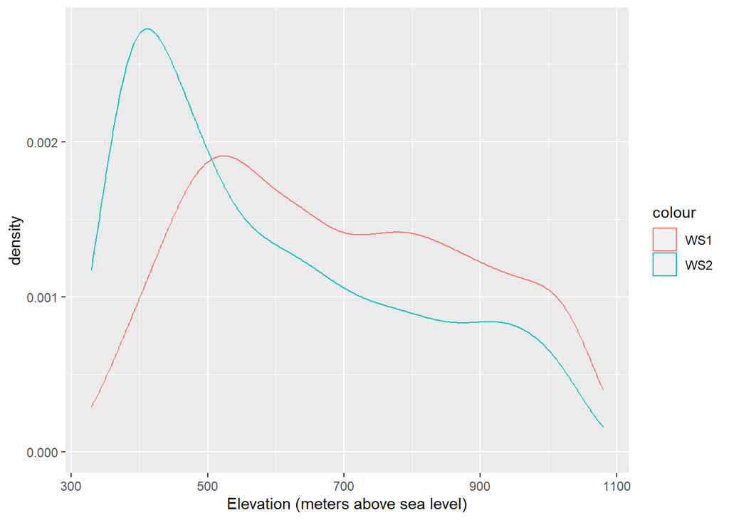

```r
#Extract DEM pixels within each watershed
wsElevs <- extract(dem, wsshape_dissolved)

WS1 = filter(wsElevs, ID == 1) #Pixels in watershed 1
WS2 = filter(wsElevs, ID == 2) #Pixels in watershed 2

ggplot() +
  geom_density(as_tibble(WS1[,2]), mapping = aes(value, color = "WS1"))+
  geom_density(as_tibble(WS2[,2]), mapping = aes(value, color = "WS2"))+
  xlab("Elevation (meters above sea level)")
```

.